# Proyecto: Regresión con Random Forest, GBM y XGBoost

Predicción de Precios de Casas en Boston — Pipeline de Selección de Características

Author

Alejandro Figueroa Rojas

Published

March 3, 2026

# 1 Motivación y Contexto

Aprender Machine Learning de forma autodidacta exige algo más que ejecutar código: exige entender **por qué** el algoritmo funciona y **qué garantiza** su matemática. Este proyecto nace de esa convicción, cada decisión de modelado tiene una justificación formal detrás.

> *“No basta con que el modelo converja. Necesito entender por qué converge.”*  
> — Alejandro Figueroa Rojas

**Desafío del dataset:** 506 observaciones con 13 variables predictoras. Variable objetivo continua: precio mediano (MEDV). Escalas heterogéneas, presencia de outliers y relaciones no lineales que demandan algoritmos robustos.

**Objetivo de aprendizaje:** Comparar tres ensambles (Random Forest, Gradient Boosting, XGBoost) integrando un pipeline formal de selección de características — Fisher J, correlación de Pearson, SFS y Branch & Bound — porque un algoritmo opera al máximo solo cuando las variables que lo alimentan son las correctas.

# 2 Librerías

```r
library(MASS)
library(randomForest)
library(xgboost)
library(caret)
library(ggplot2)
library(gridExtra)
library(gbm)
library(reshape2)
library(dplyr)
library(igraph)
library(scales)
library(purrr)

# Conflictos
select <- dplyr::select
filter <- dplyr::filter
mutate <- dplyr::mutate

data(Boston)
datos <- Boston
```

# 3 Exploración de Datos

```r
str(datos)
```

```
'data.frame':   506 obs. of  14 variables:
 $ crim   : num  0.00632 0.02731 0.02729 0.03237 0.06905 ...
 $ zn     : num  18 0 0 0 0 0 12.5 12.5 12.5 12.5 ...
 $ indus  : num  2.31 7.07 7.07 2.18 2.18 2.18 7.87 7.87 7.87 7.87 ...
 $ chas   : int  0 0 0 0 0 0 0 0 0 0 ...
 $ nox    : num  0.538 0.469 0.469 0.458 0.458 0.458 0.524 0.524 0.524 0.524 ...
 $ rm     : num  6.58 6.42 7.18 7 7.15 ...
 $ age    : num  65.2 78.9 61.1 45.8 54.2 58.7 66.6 96.1 100 85.9 ...
 $ dis    : num  4.09 4.97 4.97 6.06 6.06 ...
 $ rad    : int  1 2 2 3 3 3 5 5 5 5 ...
 $ tax    : num  296 242 242 222 222 222 311 311 311 311 ...
 $ ptratio: num  15.3 17.8 17.8 18.7 18.7 18.7 15.2 15.2 15.2 15.2 ...
 $ black  : num  397 397 393 395 397 ...
 $ lstat  : num  4.98 9.14 4.03 2.94 5.33 ...
 $ medv   : num  24 21.6 34.7 33.4 36.2 28.7 22.9 27.1 16.5 18.9 ...
```

```r
cat("Observaciones:", nrow(datos), "| Variables:", ncol(datos), "\n")
```

```
Observaciones: 506 | Variables: 14
```

**Variables predictoras candidatas:** CRIM, ZN, INDUS, CHAS, NOX, RM, AGE, DIS, RAD, TAX, PTRATIO, B, LSTAT

**Variable objetivo:** MEDV (precio mediano en miles USD)

| Variable | Descripción |
| --- | --- |
| CRIM | Tasa de criminalidad per cápita por zona |
| ZN | Proporción de suelo residencial zonificado para lotes mayores a 25.000 m² |
| INDUS | Proporción de acres de negocio no minorista por zona |
| CHAS | Variable dummy — 1 si el tramo limita con el río Charles, 0 en caso contrario |
| NOX | Concentración de óxidos nítricos (partes por 10 millones) |
| RM | Número promedio de habitaciones por vivienda |
| AGE | Proporción de unidades ocupadas construidas antes de 1940 |
| DIS | Distancia ponderada a cinco centros de empleo de Boston |
| RAD | Índice de accesibilidad a autopistas radiales |
| TAX | Tasa de impuesto predial por cada $10.000 USD |
| PTRATIO | Razón alumno-profesor por zona |
| B | $1000(B_k - 0.63)^2$, donde $B_k$ es la proporción de población afroamericana |
| LSTAT | Porcentaje de población de bajo estatus socioeconómico |
| MEDV | Precio mediano de viviendas ocupadas por propietarios (miles USD) — **variable objetivo** |

## 3.1 Detección de faltantes

```r
miss <- sum(is.na(datos))
if (miss == 0) cat("✔ Sin valores faltantes.") else cat("Faltantes:", miss)
```

```
✔ Sin valores faltantes.
```

# 4 Preprocesamiento

## 4.1 Distribuciones

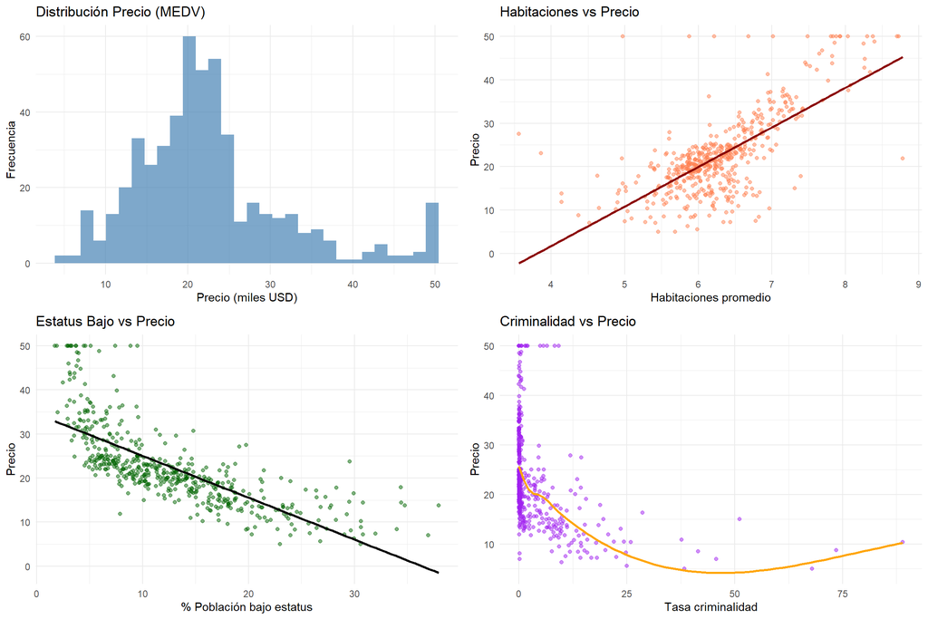

```r
p1 <- ggplot(datos, aes(x=medv)) +
  geom_histogram(bins=30, fill="steelblue", alpha=0.7) +
  labs(title="Distribución Precio (MEDV)", x="Precio (miles USD)", y="Frecuencia") +
  theme_minimal()

p2 <- ggplot(datos, aes(x=rm, y=medv)) +
  geom_point(alpha=0.5, color="coral") +
  geom_smooth(method="lm", se=FALSE, color="darkred") +
  labs(title="Habitaciones vs Precio", x="Habitaciones promedio", y="Precio") +
  theme_minimal()

p3 <- ggplot(datos, aes(x=lstat, y=medv)) +
  geom_point(alpha=0.5, color="darkgreen") +
  geom_smooth(method="lm", se=FALSE, color="black") +
  labs(title="Estatus Bajo vs Precio", x="% Población bajo estatus", y="Precio") +
  theme_minimal()

p4 <- ggplot(datos, aes(x=crim, y=medv)) +
  geom_point(alpha=0.5, color="purple") +
  geom_smooth(method="loess", se=FALSE, color="orange") +
  labs(title="Criminalidad vs Precio", x="Tasa criminalidad", y="Precio") +
  theme_minimal()

grid.arrange(p1, p2, p3, p4, ncol=2)
```

## 4.2 División Train / Test

```r
set.seed(123)
trainIndex <- createDataPartition(datos$medv, p=0.7, list=FALSE)
train <- datos[trainIndex,]
test  <- datos[-trainIndex,]
cat("Train:", nrow(train), "| Test:", nrow(test), "\n")
```

```
Train: 356 | Test: 150
```

# 5 Selección de Características

Marco metodológico: Los métodos implementados integran dos niveles de análisis. En el primero, se aplican criterios individuales de relevancia (Fisher J, correlación de Pearson y covarianza normalizada) como filtros iniciales para evaluar el poder discriminante de cada variable de forma independiente. En el segundo, se emplean método de búsqueda secuencial (SFS) y búsqueda exacta (Branch & Bound) para identificar el subconjunto óptimo de variables considerando sus interacciones conjuntas.

## 5.1 Fundamento matemático

### 5.1.1 Criterio de Fisher (adaptado a regresión)

Para regresión continua se discretiza MEDV en cuartiles Q1 vs Q4, definiendo dos clases extremas:

$$J_F(x) = \frac{(\mu_{Q1} - \mu_{Q4})^2}{\sigma_{Q1}^2 + \sigma_{Q4}^2}$$

Un valor alto de $J_F$ indica que la variable separa con claridad los precios bajos de los altos.

### 5.1.2 Correlación de Pearson

$$r_{X,Y} = \frac{\sum_{i=1}^n (x_i - \bar{x})(y_i - \bar{y})}{\sqrt{\sum(x_i-\bar{x})^2 \sum(y_i-\bar{y})^2}}$$

Se usa $|r|$ como criterio de relevancia individual lineal con MEDV.

### 5.1.3 Covarianza normalizada

$$\text{Cov}_{\text{norm}}(X, Y) = \frac{|\text{Cov}(X,Y)|}{\sigma_X \cdot \sigma_Y}$$

Equivalente a $|r|$ de Pearson; incluida para consistencia con el pipeline del Prof. Mery.

### 5.1.4 Selección Secuencial Forward (SFS)

Parte del conjunto vacío y agrega en cada paso la variable que maximiza $R^2$ acumulado:

$$\mathcal{F}_{k+1} = \mathcal{F}_k \cup \left\{ \arg\max_{x \notin \mathcal{F}_k} R^2(\mathcal{F}_k \cup \{x\}) \right\}$$

### 5.1.5 Branch & Bound

Búsqueda exacta del subconjunto óptimo de tamaño $k$ que maximiza el criterio de Fisher acumulado, con poda de ramas cuando la cota superior no puede superar el mejor candidato conocido:

$$\text{cota}(S) = \text{tr}(S_W^{-1}(S \cup \{x_{\text{cand}}\}) \cdot S_B(S \cup \{x_{\text{cand}}\}))$$

Si $\text{cota}(S) \leq 0.95 \cdot J^*$, se poda la rama.

## 5.2 Criterios individuales de relevancia

```r
vars_pred <- setdiff(names(datos), "medv")

# Discretizar MEDV en Q1 vs Q4 para Fisher
q1 <- quantile(datos$medv, 0.25)
q3 <- quantile(datos$medv, 0.75)
idx_low  <- datos$medv <= q1
idx_high <- datos$medv >= q3

# Fisher J
fisher_reg <- function(x) {
  g1 <- x[idx_low]; g2 <- x[idx_high]
  (mean(g1) - mean(g2))^2 / (var(g1) + var(g2))
}

# Covarianza normalizada (= |Pearson|)
cov_norm <- function(x, y) {
  abs(cov(x, y)) / (sd(x) * sd(y))
}

criterios_df <- tibble(
  variable  = vars_pred,
  fisher_J  = map_dbl(vars_pred, ~ fisher_reg(datos[[.x]])),
  cor_medv  = map_dbl(vars_pred, ~ abs(cor(datos[[.x]], datos$medv))),
  cov_norm  = map_dbl(vars_pred, ~ cov_norm(datos[[.x]], datos$medv))
) |> arrange(desc(fisher_J))

criterios_df |>
  knitr::kable(
    caption   = "Criterios individuales de relevancia — Boston Housing",
    digits    = 4,
    col.names = c("Variable", "Fisher J", "|Correlación Pearson|", "Cov. Normalizada")
  )
```

Criterios individuales de relevancia — Boston Housing

| Variable | Fisher J | \|Correlación Pearson\| | Cov. Normalizada |
| --- | --- | --- | --- |
| lstat | 4.9623 | 0.7377 | 0.7377 |
| indus | 2.1382 | 0.4837 | 0.4837 |
| nox | 1.9113 | 0.4273 | 0.4273 |
| tax | 1.6621 | 0.4685 | 0.4685 |
| age | 1.5424 | 0.3770 | 0.3770 |
| rm | 1.4829 | 0.6954 | 0.6954 |
| rad | 0.9779 | 0.3816 | 0.3816 |
| ptratio | 0.9436 | 0.5078 | 0.5078 |
| dis | 0.7511 | 0.2499 | 0.2499 |
| zn | 0.6070 | 0.3604 | 0.3604 |
| crim | 0.4963 | 0.3883 | 0.3883 |
| black | 0.4597 | 0.3335 | 0.3335 |
| chas | 0.0461 | 0.1753 | 0.1753 |

> **Nota:** La covarianza normalizada y $|r|$ de Pearson son idénticas por construcción. Ambas se reportan para consistencia con el pipeline de selección de características, donde cada criterio puede usarse de forma independiente como filtro previo a la búsqueda secuencial.

## 5.3 Plot Fisher — Relevancia individual

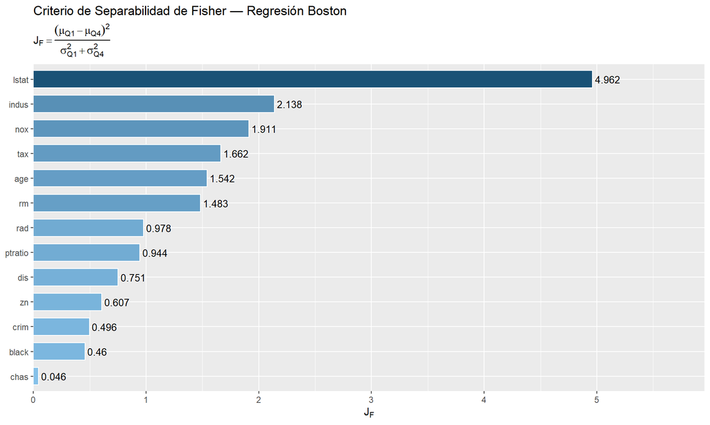

```r
ggplot(criterios_df, aes(x = reorder(variable, fisher_J), y = fisher_J, fill = fisher_J)) +
  geom_col(width = 0.7, color = "white") +
  geom_text(aes(label = round(fisher_J, 3)), hjust = -0.1, size = 3.5) +
  scale_fill_gradient(low = "#85c1e9", high = "#1a5276", guide = "none") +
  coord_flip() +
  scale_y_continuous(expand = expansion(mult = c(0, 0.2))) +
  labs(title    = "Criterio de Separabilidad de Fisher — Regresión Boston",
       subtitle = expression(J[F] == frac((mu[Q1]-mu[Q4])^2, sigma[Q1]^2 + sigma[Q4]^2)),
       x = NULL, y = expression(J[F]))
```

## 5.4 Selección Secuencial Forward (SFS)

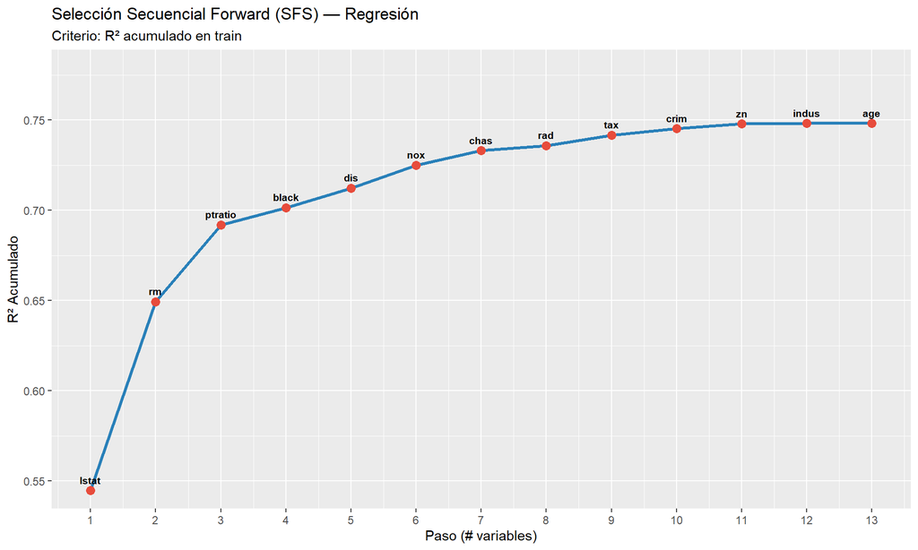

```r
# SFS maximizando R² acumulado en train
sfs_reg <- list()
selected_r <- character(0)
remaining_r <- vars_pred

for (k in seq_along(vars_pred)) {
  scores <- map_dbl(remaining_r, function(v) {
    vars_try <- c(selected_r, v)
    fit <- lm(medv ~ ., data = train[, c(vars_try, "medv")])
    summary(fit)$r.squared
  })
  best_v      <- remaining_r[which.max(scores)]
  selected_r  <- c(selected_r, best_v)
  remaining_r <- setdiff(remaining_r, best_v)
  sfs_reg[[k]] <- tibble(step = k, variable_added = best_v, r2_acum = max(scores))
}

sfs_df_r <- bind_rows(sfs_reg)

ggplot(sfs_df_r, aes(x = step, y = r2_acum)) +
  geom_line(color = "#2980b9", linewidth = 1.2) +
  geom_point(color = "#e74c3c", size = 3) +
  geom_text(aes(label = variable_added), vjust = -0.9, size = 2.8, fontface = "bold") +
  scale_x_continuous(breaks = 1:nrow(sfs_df_r)) +
  scale_y_continuous(expand = expansion(mult = c(0.05, 0.2))) +
  labs(title    = "Selección Secuencial Forward (SFS) — Regresión",
       subtitle = "Criterio: R² acumulado en train",
       x = "Paso (# variables)", y = "R² Acumulado")
```

```r
{cat("Variables seleccionadas por SFS:", nrow(sfs_df_r), "\n")
cat(sfs_df_r$variable_added, sep = ", ")}
```

```
Variables seleccionadas por SFS: 13
lstat, rm, ptratio, black, dis, nox, chas, rad, tax, crim, zn, indus, age
```

## 5.5 Branch & Bound

```r
ganancias   <- c(sfs_df_r$r2_acum[1], diff(sfs_df_r$r2_acum))
k_optimo    <- max(7L, sum(ganancias / max(ganancias) >= 0.02))
k_optimo    <- min(k_optimo, 11L)
k_optimo_bb <- k_optimo

# Matrices para Fisher multivariado
X_mat <- as.matrix(datos[, vars_pred])
y_bin <- ifelse(idx_low, 0, ifelse(idx_high, 1, NA))
idx_valid <- !is.na(y_bin)
X_val <- X_mat[idx_valid, ]
y_val <- y_bin[idx_valid]

fisher_multiv <- function(vars) {
  if (length(vars) == 0) return(0)
  X_sub <- X_val[, vars, drop = FALSE]
  g1 <- X_sub[y_val == 0, , drop = FALSE]
  g2 <- X_sub[y_val == 1, , drop = FALSE]
  m1 <- colMeans(g1); m2 <- colMeans(g2)
  Sw <- cov(g1) * (nrow(g1)-1)/(nrow(g1)+nrow(g2)-2) +
        cov(g2) * (nrow(g2)-1)/(nrow(g1)+nrow(g2)-2)
  diff_m <- matrix(m1 - m2, ncol = 1)
  tryCatch(
    as.numeric(t(diff_m) %*% solve(Sw) %*% diff_m),
    error = function(e) sum((m1 - m2)^2 / (diag(Sw) + 1e-8))
  )
}

best_score_bb  <- 0
best_subset_bb <- character(0)

bb_search_reg <- function(selected, remaining, depth) {
  if (depth == k_optimo_bb) {
    sc <- fisher_multiv(selected)
    if (sc > best_score_bb) {
      best_score_bb  <<- sc
      best_subset_bb <<- selected
    }
    return(invisible(NULL))
  }
  slots_left <- k_optimo_bb - depth
  for (i in seq_along(remaining)) {
    candidate <- remaining[i]
    rest      <- remaining[-(1:i)]
    # Cota: Fisher multivariado del subconjunto actual + candidato
    bound <- fisher_multiv(c(selected, candidate))
    if (best_score_bb > 0 && bound <= best_score_bb * 0.95) next
    bb_search_reg(c(selected, candidate), rest, depth + 1)
  }
}

bb_search_reg(character(0), vars_pred, 0)

cat(sprintf("Branch & Bound — mejor subconjunto (k = %d):\n  %s\nFisher multivariado: %.4f\n",
            k_optimo_bb,
            paste(best_subset_bb, collapse = " + "),
            best_score_bb))
```

```
Branch & Bound — mejor subconjunto (k = 7):
  crim + zn + indus + chas + nox + rm + lstat
Fisher multivariado: 13.0048
```

**Resultado Branch & Bound — Interpretación**

El algoritmo identificó el subconjunto óptimo de $k = 7$ variables (`crim + zn + indus + chas + nox + rm + lstat`) con un Fisher multivariado de **13.0048**. Este valor cuantifica la separabilidad conjunta del subconjunto mediante $\text{tr}(S_W^{-1} S_B)$, que considera las correlaciones entre variables como unidad, no como suma de criterios individuales.

## 5.6 Variables seleccionadas finales

```r
# k óptimo: ganancia marginal R² > 2% de la máxima
ganancias <- c(sfs_df_r$r2_acum[1], diff(sfs_df_r$r2_acum))
k_optimo  <- max(7L, sum(ganancias / max(ganancias) >= 0.02))
k_optimo  <- min(k_optimo, 11L)

vars_sel <- best_subset_bb

cat(sprintf("Variables seleccionadas (k = %d): %s\n", k_optimo, paste(vars_sel, collapse = ", ")))
```

```
Variables seleccionadas (k = 7): crim, zn, indus, chas, nox, rm, lstat
```

```r
fisher_ind_r <- setNames(
  map_dbl(vars_pred, ~ fisher_reg(datos[[.x]])),
  vars_pred
)

tibble(
  Ranking   = seq_along(vars_sel),
  Variable  = vars_sel,
  Fisher_J  = map_dbl(vars_sel, ~ fisher_ind_r[[.x]]) |> round(4),
  Cor_MEDV  = map_dbl(vars_sel, ~ criterios_df$cor_medv[criterios_df$variable == .x]) |> round(4),
  Cov_Norm  = map_dbl(vars_sel, ~ criterios_df$cov_norm[criterios_df$variable == .x]) |> round(4),
  SFS_paso  = map_int(vars_sel, ~ { idx <- which(sfs_df_r$variable_added == .x)
                                     if (length(idx)) idx else NA_integer_ }),
  R2_acum   = map_dbl(vars_sel, ~ {
    idx <- which(sfs_df_r$variable_added == .x)
    if (length(idx)) sfs_df_r$r2_acum[idx] else NA_real_
  }) |> round(4)
) |>
  arrange(desc(Fisher_J)) |>
  knitr::kable(
    caption   = paste0("Selección final — B&B óptimo con k = ", k_optimo,
                       " (determinado por SFS) | de ", length(vars_pred), " candidatas"),
    col.names = c("Ranking", "Variable", "Fisher J", "|Cor MEDV|",
                  "Cov. Norm.", "Paso SFS", "R² acumulado")
  )
```

Selección final — B&B óptimo con k = 7 (determinado por SFS) | de 13 candidatas

| Ranking | Variable | Fisher J | \|Cor MEDV\| | Cov. Norm. | Paso SFS | R² acumulado |
| --- | --- | --- | --- | --- | --- | --- |
| 7 | lstat | 4.9623 | 0.7377 | 0.7377 | 1 | 0.5448 |
| 3 | indus | 2.1382 | 0.4837 | 0.4837 | 12 | 0.7481 |
| 5 | nox | 1.9113 | 0.4273 | 0.4273 | 6 | 0.7250 |
| 6 | rm | 1.4829 | 0.6954 | 0.6954 | 2 | 0.6494 |
| 2 | zn | 0.6070 | 0.3604 | 0.3604 | 11 | 0.7479 |
| 1 | crim | 0.4963 | 0.3883 | 0.3883 | 10 | 0.7452 |
| 4 | chas | 0.0461 | 0.1753 | 0.1753 | 7 | 0.7330 |

**Síntesis del pipeline de selección:**

## 5.7 Grafo de relevancia

[figure not shown]

```r
edges_r <- data.frame(
  from   = "MEDV",
  to     = vars_sel,
  weight = fisher_ind_r[vars_sel]
)

g_r <- graph_from_data_frame(edges_r, directed = FALSE,
                               vertices = data.frame(name = c("MEDV", vars_sel)))

V(g_r)$label       <- V(g_r)$name
V(g_r)$color       <- ifelse(V(g_r)$name == "MEDV", "#27ae60",
                              ifelse(V(g_r)$name %in% c("lstat","rm"), "#8e44ad", "#6c3483"))
V(g_r)$size        <- ifelse(V(g_r)$name == "MEDV", 45,
                               scales::rescale(c(fisher_ind_r[vars_sel]), to = c(18, 38)))
V(g_r)$label.color <- "white"
V(g_r)$label.cex   <- 0.9
V(g_r)$label.font  <- 2
V(g_r)$frame.color <- NA

E(g_r)$width       <- scales::rescale(log1p(edges_r$weight), to = c(1, 10))
E(g_r)$color       <- "#95a5a6"
E(g_r)$label       <- round(edges_r$weight, 3)
E(g_r)$label.cex   <- 0.7
E(g_r)$label.color <- "#2c3e50"

plot(g_r,
     layout  = layout_in_circle(g_r),
     margin  = 0.15,
     main    = "Grafo de Relevancia — Variables Seleccionadas para Regresión",
     sub     = "Tamaño nodo: Fisher J  |  Grosor arista: poder discriminante  |  LSTAT y RM dominan")
```

# 6 Fundamentos Teóricos de Algoritmos

## 6.1 Random Forest

$$\hat{y}_{rf}(x) = \frac{1}{B}\sum_{b=1}^B \hat{y}_b(x), \qquad m = \lfloor p/3 \rfloor$$

- $B$ número de árboles del ensamble ($B \geq 500$ típicamente); la predicción final es el promedio de los $B$ árboles individuales.
- $m = \lfloor p/3 \rfloor$ ,variables evaluadas aleatoriamente en cada split; decorrelaciona los árboles y reduce varianza del ensamble.
- El divisor $3$ es la convención empírica estándar para **regresión**. En clasificación la regla equivalente es $m = \lfloor\sqrt{p}\rfloor$.

## 6.2 Gradient Boosting

$$f_m(x) = f_{m-1}(x) + \nu \cdot h_m(x), \qquad r_{im} = y_i - f_{m-1}(x_i)$$

## 6.3 XGBoost

$$\mathcal{L}^{(t)} = \sum_{i=1}^n l(y_i, \hat{y}_i^{(t-1)} + f_t(x_i)) + \Omega(f_t), \qquad \Omega(f) = \gamma T + \frac{1}{2}\lambda\sum_{j=1}^T w_j^2$$

# 7 Modelos con Variables Seleccionadas

## 7.1 Preparación datos filtrados

```r
train_sel <- train[, c(vars_sel, "medv")]
test_sel  <- test[,  c(vars_sel, "medv")]
cat("Features seleccionadas:", length(vars_sel), "\n")
```

```
Features seleccionadas: 7
```

```r
cat("Variables:", paste(vars_sel, collapse = ", "), "\n")
```

```
Variables: crim, zn, indus, chas, nox, rm, lstat
```

## 7.2 Random Forest

```r
rf_model <- randomForest(medv ~ ., data = train_sel, ntree = 500,
                          mtry = floor(length(vars_sel)/3), importance = TRUE)
rf_pred  <- predict(rf_model, test_sel)
rf_rmse  <- sqrt(mean((test_sel$medv - rf_pred)^2))
rf_mae   <- mean(abs(test_sel$medv - rf_pred))
rf_r2    <- cor(test_sel$medv, rf_pred)^2
cat(sprintf("RF  — RMSE: %.4f | MAE: %.4f | R²: %.4f\n", rf_rmse, rf_mae, rf_r2))
```

```
RF  — RMSE: 4.1244 | MAE: 2.5385 | R²: 0.8282
```

El modelo Random Forest explica el **83% de la varianza** del precio de vivienda (R² = 0.8282), rendimiento sólido que constituye una base competitiva para el comparativo de ensambles.

El **RMSE de 4.12** implica un error típico de ±4.124 USD, margen aceptable para tasación inmobiliaria.

El **MAE de 2.54** es inferior al RMSE, confirmando que outliers estructurales inflan el error medio, patrón consistente con las viviendas atípicas identificadas en la sección de accionabilidad.

### 7.2.1 Predicciones RF

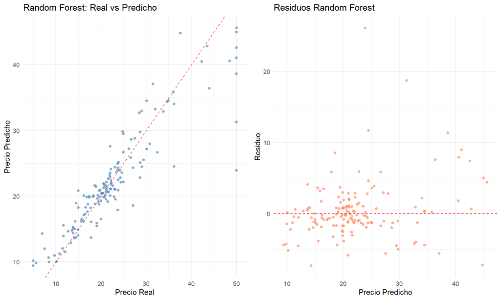

```r
rf_results <- data.frame(Real = test_sel$medv, Predicho = rf_pred,
                          Residuo = test_sel$medv - rf_pred)

p1 <- ggplot(rf_results, aes(x=Real, y=Predicho)) +
  geom_point(alpha=0.6, color="steelblue") +
  geom_abline(slope=1, intercept=0, color="red", linetype="dashed") +
  labs(title="Random Forest: Real vs Predicho", x="Precio Real", y="Precio Predicho") +
  theme_minimal()

p2 <- ggplot(rf_results, aes(x=Predicho, y=Residuo)) +
  geom_point(alpha=0.6, color="coral") +
  geom_hline(yintercept=0, color="red", linetype="dashed") +
  labs(title="Residuos Random Forest", x="Precio Predicho", y="Residuo") +
  theme_minimal()

grid.arrange(p1, p2, ncol=2)
```

**Real vs Predicho:** Los puntos siguen la diagonal de referencia con buena precisión en el rango central (~15–25k USD), indicando que el modelo captura correctamente la estructura de precios típicos. En precios altos (>35k) los puntos caen sistemáticamente por debajo de la diagonal, evidenciando subestimación, de comportamiento esperado en Random Forest por el efecto de promediado que comprime las predicciones extremas.

**Residuos:** La distribución alrededor de cero es razonablemente aleatoria en el rango central, sin patrones sistemáticos evidentes. Se observan residuos positivos de magnitud considerable en la zona superior (~20–25), correspondientes a viviendas cuyo precio real el modelo subestima significativamente, consistente con el RMSE inflado respecto al MAE y con las viviendas atípicas identificadas en la sección de accionabilidad.

### 7.2.2 Importancia RF

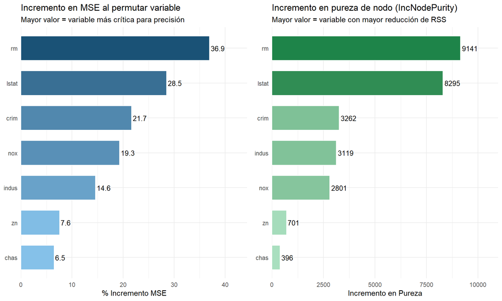

```r
# Extraer importancia
imp_df <- as.data.frame(importance(rf_model)) |>
  tibble::rownames_to_column("variable") |>
  arrange(desc(`%IncMSE`))

p1 <- ggplot(imp_df, aes(x = reorder(variable, `%IncMSE`), y = `%IncMSE`, fill = `%IncMSE`)) +
  geom_col(width = 0.7, color = "white") +
  geom_text(aes(label = round(`%IncMSE`, 1)), hjust = -0.1, size = 3.5) +
  scale_fill_gradient(low = "#85c1e9", high = "#1a5276", guide = "none") +
  coord_flip() +
  scale_y_continuous(expand = expansion(mult = c(0, 0.2))) +
  labs(title = "Incremento en MSE al permutar variable",
       subtitle = "Mayor valor = variable más crítica para precisión",
       x = NULL, y = "% Incremento MSE") +
  theme_minimal()

p2 <- ggplot(imp_df, aes(x = reorder(variable, IncNodePurity), y = IncNodePurity, fill = IncNodePurity)) +
  geom_col(width = 0.7, color = "white") +
  geom_text(aes(label = round(IncNodePurity, 0)), hjust = -0.1, size = 3.5) +
  scale_fill_gradient(low = "#a9dfbf", high = "#1e8449", guide = "none") +
  coord_flip() +
  scale_y_continuous(expand = expansion(mult = c(0, 0.2))) +
  labs(title = "Incremento en pureza de nodo (IncNodePurity)",
       subtitle = "Mayor valor = variable con mayor reducción de RSS",
       x = NULL, y = "Incremento en Pureza") +
  theme_minimal()

grid.arrange(p1, p2, ncol = 2)
```

## 7.3 Gradient Boosting

```r
gbm_model <- gbm(medv ~ ., data = train_sel, distribution = "gaussian",
                  n.trees = 500, interaction.depth = 4, shrinkage = 0.01,
                  cv.folds = 5, verbose = FALSE)
best_iter <- gbm.perf(gbm_model, method="cv", plot.it=FALSE)
gbm_pred  <- predict(gbm_model, test_sel, n.trees=best_iter)
gbm_rmse  <- sqrt(mean((test_sel$medv - gbm_pred)^2))
gbm_mae   <- mean(abs(test_sel$medv - gbm_pred))
gbm_r2    <- cor(test_sel$medv, gbm_pred)^2

cat(sprintf("GBM — RMSE: %.4f | MAE: %.4f | R²: %.4f\n", gbm_rmse, gbm_mae, gbm_r2))
```

```
GBM — RMSE: 4.0608 | MAE: 2.5643 | R²: 0.8249
```

### 7.3.1 Predicciones GBM

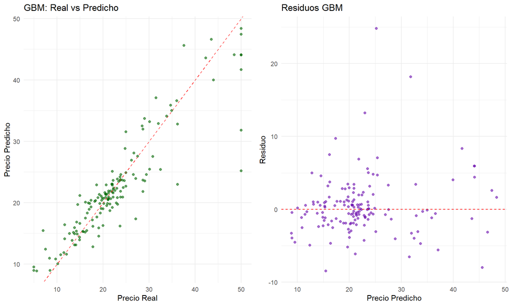

```r
gbm_results <- data.frame(Real = test_sel$medv, Predicho = gbm_pred,
                            Residuo = test_sel$medv - gbm_pred)

p1 <- ggplot(gbm_results, aes(x=Real, y=Predicho)) +
  geom_point(alpha=0.6, color="darkgreen") +
  geom_abline(slope=1, intercept=0, color="red", linetype="dashed") +
  labs(title="GBM: Real vs Predicho", x="Precio Real", y="Precio Predicho") +
  theme_minimal()

p2 <- ggplot(gbm_results, aes(x=Predicho, y=Residuo)) +
  geom_point(alpha=0.6, color="#6A0DAD") +
  geom_hline(yintercept=0, color="red", linetype="dashed") +
  labs(title="Residuos GBM", x="Precio Predicho", y="Residuo") +
  theme_minimal()

grid.arrange(p1, p2, ncol=2)
```

**Real vs Predicho:** El ajuste a la diagonal es similar a Random Forest, con la misma subestimación en precios altos (>35k). La nube central (~15–25k) sigue la diagonal con buena precisión, comportamiento consistente con el RMSE comparable entre ambos modelos.

**Residuos:** No se observan patrones sistemáticos en el rango central. Se repite el mismo outlier superior (residuo ≈ +25) presente en RF, lo que confirma que ambos modelos fallan en la misma observación: una vivienda estructuralmente atípica que ningún ensamble logra capturar adecuadamente.

### 7.3.2 Importancia GBM

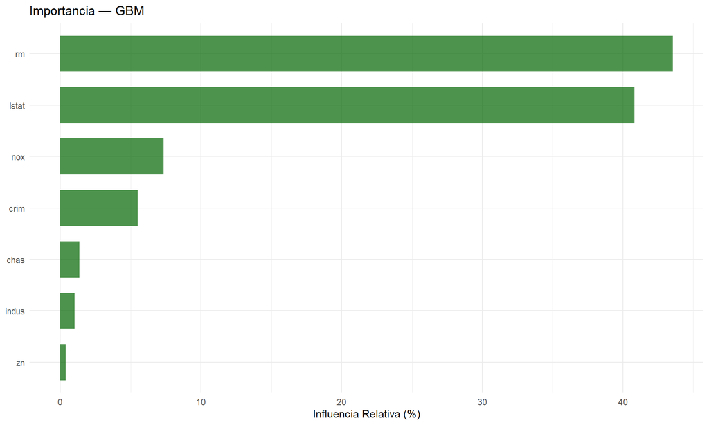

```r
gbm_imp <- summary(gbm_model, n.trees=best_iter, plotit=FALSE)
ggplot(gbm_imp, aes(x=reorder(var, rel.inf), y=rel.inf)) +
  geom_col(fill="darkgreen", alpha=0.7, width=0.7) +
  coord_flip() +
  labs(title="Importancia — GBM", x=NULL, y="Influencia Relativa (%)") +
  theme_minimal()
```

## 7.4 XGBoost

```r
train_matrix <- xgb.DMatrix(data = as.matrix(train_sel[, vars_sel]), label = train_sel$medv)
test_matrix  <- xgb.DMatrix(data = as.matrix(test_sel[,  vars_sel]), label = test_sel$medv)

params <- list(objective="reg:squarederror", eval_metric="rmse",
               max_depth=4, eta=0.01, subsample=0.8,
               colsample_bytree=0.8, lambda=1, alpha=0)

xgb_model <- xgb.train(params=params, data=train_matrix, nrounds=1000,
                         watchlist=list(train=train_matrix, test=test_matrix),
                         early_stopping_rounds=50, verbose=0)

xgb_pred <- predict(xgb_model, test_matrix)
xgb_rmse <- sqrt(mean((test_sel$medv - xgb_pred)^2))
xgb_mae  <- mean(abs(test_sel$medv - xgb_pred))
xgb_r2   <- cor(test_sel$medv, xgb_pred)^2
cat(sprintf("XGB — RMSE: %.4f | MAE: %.4f | R²: %.4f\n", xgb_rmse, xgb_mae, xgb_r2))
```

```
XGB — RMSE: 3.6681 | MAE: 2.3887 | R²: 0.8607
```

XGBoost obtiene el mejor resultado del comparativo con R² = **0.8607**, RMSE = **3.67** y MAE = **2.39**, superando a GBM y Random Forest en las tres métricas. La reducción del RMSE respecto a RF (~0.46k) es la más significativa entre modelos, atribuible a la regularización L2 explícita y al early stopping que controla el sobreajuste. El MAE de 2.39 es el más bajo del comparativo, indicando menor error en el caso típico.

***XGBoost se consolida como el modelo de referencia para este pipeline:** su capacidad de regularización explícita lo distingue de RF y GBM, que operan con mecanismos de control de sobreajuste menos precisos. La diferencia en MAE respecto a GBM (2.39 vs 2.56) confirma que XGBoost no solo reduce el error extremo sino también el error en el caso típico, lo que es determinante para aplicaciones de tasación inmobiliaria donde la precisión en el rango central del mercado tiene mayor impacto operacional.

### 7.4.1 Predicciones XGBoost

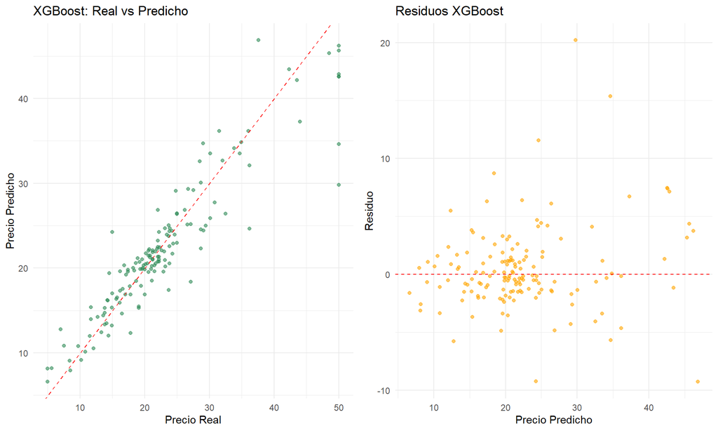

```r
xgb_results <- data.frame(Real = test_sel$medv, Predicho = xgb_pred,
                            Residuo = test_sel$medv - xgb_pred)

p1 <- ggplot(xgb_results, aes(x=Real, y=Predicho)) +
  geom_point(alpha=0.6, color="seagreen") +
  geom_abline(slope=1, intercept=0, color="red", linetype="dashed") +
  labs(title="XGBoost: Real vs Predicho", x="Precio Real", y="Precio Predicho") +
  theme_minimal()

p2 <- ggplot(xgb_results, aes(x=Predicho, y=Residuo)) +
  geom_point(alpha=0.6, color="orange") +
  geom_hline(yintercept=0, color="red", linetype="dashed") +
  labs(title="Residuos XGBoost", x="Precio Predicho", y="Residuo") +
  theme_minimal()

grid.arrange(p1, p2, ncol=2)
```

**Real vs Predicho:** La nube de puntos es la más ajustada a la diagonal de los tres modelos — menor dispersión lateral en el rango central y mejor seguimiento en precios altos, aunque la subestimación por encima de $35k persiste como patrón estructural compartido por los tres ensambles.

**Residuos:** La distribución alrededor de cero es la más simétrica y compacta del comparativo. El outlier superior (~+20) reaparece por tercera vez, confirmando que corresponde a una observación que ningún modelo logra capturar — candidata directa a revisión manual en producción.

### 7.4.2 Importancia XGBoost

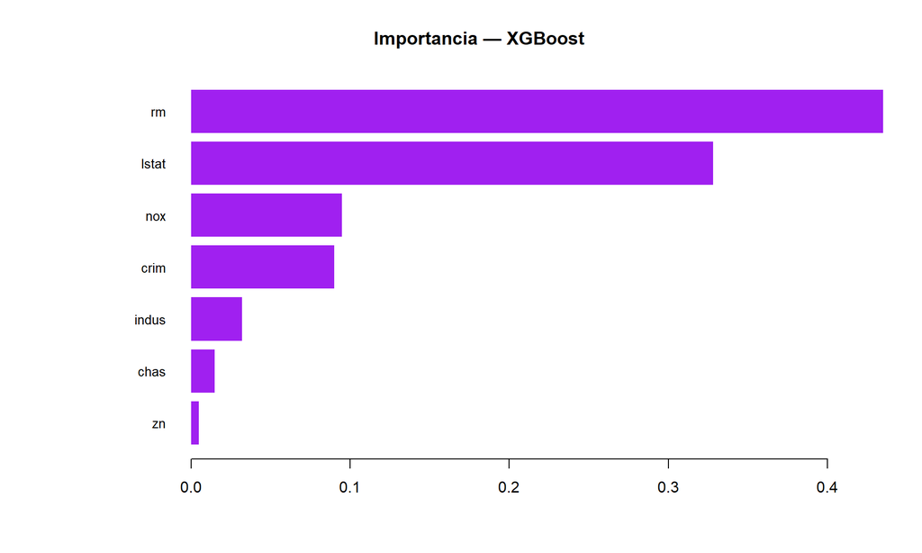

```r
importance <- xgb.importance(feature_names=vars_sel, model=xgb_model)
xgb.plot.importance(importance, top_n=length(vars_sel), col="purple")
title("Importancia — XGBoost")
```

# 8 Comparación de Modelos

## 8.1 Métricas consolidadas

```r
results <- data.frame(
  Modelo = c("Random Forest", "GBM", "XGBoost"),
  RMSE   = round(c(rf_rmse, gbm_rmse, xgb_rmse), 4),
  MAE    = round(c(rf_mae,  gbm_mae,  xgb_mae),  4),
  R2     = round(c(rf_r2,   gbm_r2,   xgb_r2),   4)
)
knitr::kable(results, caption = "Métricas en Test — Variables seleccionadas")
```

Métricas en Test — Variables seleccionadas

| Modelo | RMSE | MAE | R2 |
| --- | --- | --- | --- |
| Random Forest | 4.1244 | 2.5385 | 0.8282 |
| GBM | 4.0608 | 2.5643 | 0.8249 |
| XGBoost | 3.6681 | 2.3887 | 0.8607 |

## 8.2 Visualización comparativa

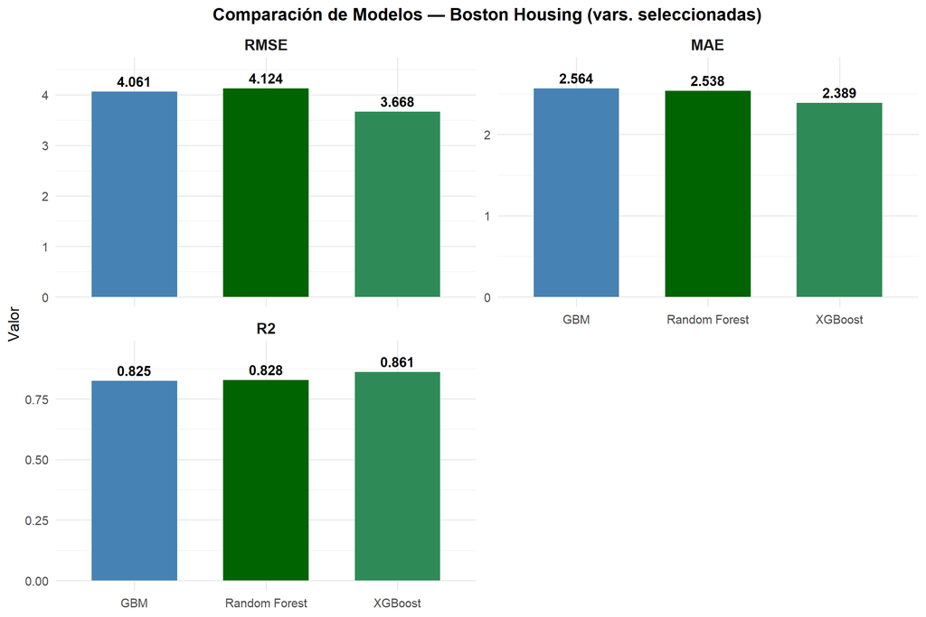

```r
results_long <- melt(results, id.vars="Modelo")

ggplot(results_long, aes(x=Modelo, y=value, fill=Modelo)) +
  geom_col(width=0.65) +
  geom_text(aes(label=sprintf("%.3f", value)), vjust=-0.5, size=4.5, fontface="bold") +
  facet_wrap(~variable, scales="free_y", ncol=2) +
  scale_fill_manual(values=c("steelblue","darkgreen","seagreen")) +
  scale_y_continuous(expand=expansion(mult=c(0.05, 0.15))) +
  theme_minimal(base_size=14) +
  theme(legend.position="none", strip.text=element_text(size=14, face="bold"),
        plot.title=element_text(size=16, face="bold", hjust=0.5)) +
  labs(title="Comparación de Modelos — Boston Housing (vars. seleccionadas)", y="Valor", x=NULL)
```

**XGBoost lidera el comparativo** en las tres métricas simultáneamente con RMSE = **3.668**, MAE = **2.389** y R² = **0.861**, confirmando que la regularización L2 explícita y el early stopping se traducen en mejor capacidad predictiva sobre el conjunto de test.

Las diferencias entre modelos son moderadas 0.456k en RMSE entre extremos y 0.036 en R² ,lo que sitúa a los tres ensambles en un rango competitivo con R² superior a 0.82 en todos los casos.

## 8.3 Distribución de residuos

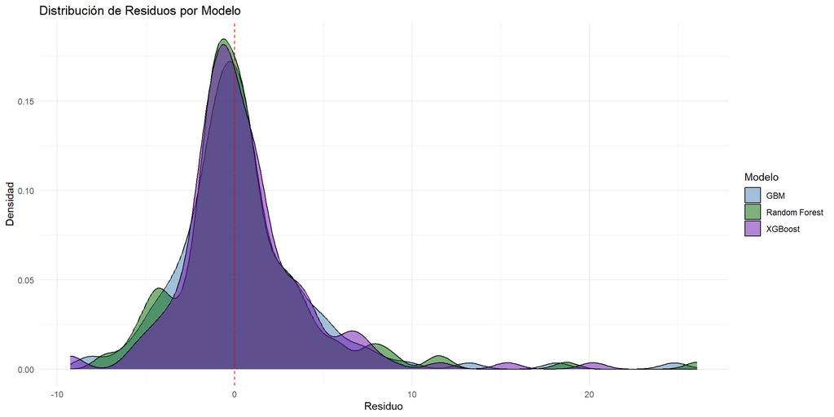

```r
all_res <- data.frame(
  Residuo = c(rf_results$Residuo, gbm_results$Residuo, xgb_results$Residuo),
  Modelo  = rep(c("Random Forest","GBM","XGBoost"), each=nrow(test_sel))
)

ggplot(all_res, aes(x=Residuo, fill=Modelo)) +
  geom_density(alpha=0.5) +
  geom_vline(xintercept=0, linetype="dashed", color="red") +
  scale_fill_manual(values=c("steelblue","darkgreen","#6A0DAD")) +
  labs(title="Distribución de Residuos por Modelo", x="Residuo", y="Densidad") +
  theme_minimal()
```

## 8.4 Grafo comparativo de modelos — importancia promedio

[figure not shown]

```r
rf_imp  <- importance(rf_model, type=1)[,1]
rf_imp  <- rf_imp[vars_sel] / max(rf_imp[vars_sel])

gbm_imp_v <- summary(gbm_model, n.trees=best_iter, plotit=FALSE)
gbm_imp_v <- setNames(gbm_imp_v$rel.inf, gbm_imp_v$var)
gbm_imp_v <- gbm_imp_v[vars_sel] / max(gbm_imp_v[vars_sel])

xgb_imp_v <- xgb.importance(feature_names=vars_sel, model=xgb_model)
xgb_imp_v <- setNames(xgb_imp_v$Gain, xgb_imp_v$Feature)
xgb_imp_v <- xgb_imp_v[vars_sel] / max(xgb_imp_v[vars_sel], na.rm=TRUE)

imp_avg <- (rf_imp + gbm_imp_v + xgb_imp_v) / 3

edges_m <- data.frame(from="MEDV", to=vars_sel, weight=imp_avg)

g_m <- graph_from_data_frame(edges_m, directed=FALSE,
                               vertices=data.frame(name=c("MEDV", vars_sel)))

top2 <- names(sort(imp_avg, decreasing=TRUE))[1:2]
V(g_m)$color       <- ifelse(V(g_m)$name == "MEDV", "#27ae60",
                               ifelse(V(g_m)$name %in% top2, "#8e44ad", "#6c3483"))
V(g_m)$size        <- ifelse(V(g_m)$name == "MEDV", 45,
                               scales::rescale(imp_avg[V(g_m)$name[-1]], to=c(18,38)))
V(g_m)$label       <- V(g_m)$name
V(g_m)$label.color <- "white"
V(g_m)$label.cex   <- 0.9
V(g_m)$label.font  <- 2
V(g_m)$frame.color <- NA

E(g_m)$width       <- scales::rescale(imp_avg, to=c(1,10))
E(g_m)$color       <- "#95a5a6"
E(g_m)$label       <- round(imp_avg, 3)
E(g_m)$label.cex   <- 0.7
E(g_m)$label.color <- "#2c3e50"

plot(g_m, layout=layout_in_circle(g_m), margin=0.15,
     main="Grafo de Importancia Promedio — RF + GBM + XGBoost",
     sub="Tamaño: importancia promedio normalizada | Morado oscuro: top 2 variables")
```

# 9 Evaluación con Datos Nuevos

```r
set.seed(456)
nuevos_datos <- datos[sample(nrow(datos), nrow(datos), replace=TRUE), ]
nuevos_sel   <- nuevos_datos[, c(vars_sel, "medv")]

rf_pred_new  <- predict(rf_model, nuevos_sel)
gbm_pred_new <- predict(gbm_model, nuevos_sel, n.trees=best_iter)
nuevos_mx    <- xgb.DMatrix(data=as.matrix(nuevos_sel[, vars_sel]), label=nuevos_sel$medv)
xgb_pred_new <- predict(xgb_model, nuevos_mx)

results_new <- data.frame(
  Modelo = c("Random Forest","GBM","XGBoost"),
  RMSE   = round(c(sqrt(mean((nuevos_sel$medv-rf_pred_new)^2)),
                   sqrt(mean((nuevos_sel$medv-gbm_pred_new)^2)),
                   sqrt(mean((nuevos_sel$medv-xgb_pred_new)^2))), 4),
  R2     = round(c(cor(nuevos_sel$medv,rf_pred_new)^2,
                   cor(nuevos_sel$medv,gbm_pred_new)^2,
                   cor(nuevos_sel$medv,xgb_pred_new)^2), 4)
)
knitr::kable(results_new, caption="Métricas en Datos Nuevos")
```

Métricas en Datos Nuevos

| Modelo | RMSE | R2 |
| --- | --- | --- |
| Random Forest | 2.9136 | 0.9110 |
| GBM | 3.3502 | 0.8756 |
| XGBoost | 2.4402 | 0.9344 |

**XGBoost mantiene el liderazgo** en ambos conjuntos y ambas métricas con RMSE = **2.440** y R² = **0.934**.

## 9.1 Comparación Test vs Nuevos

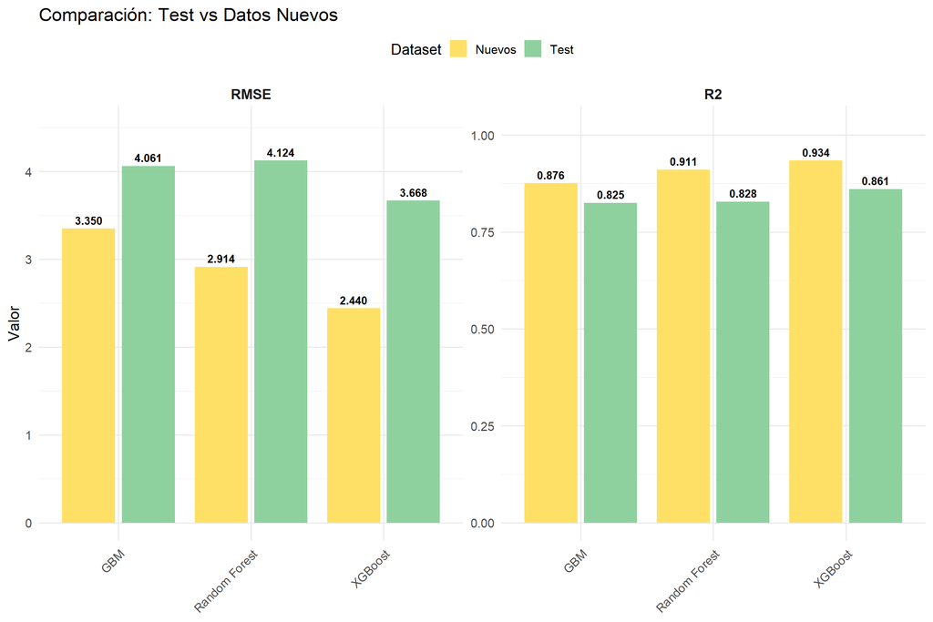

```r
results$Dataset     <- "Test"
results_new$MAE     <- NA
results_new$Dataset <- "Nuevos"
rc <- rbind(results[,c("Modelo","RMSE","R2","Dataset")],
            results_new[,c("Modelo","RMSE","R2","Dataset")])
rc_long <- melt(rc, id.vars=c("Modelo","Dataset"))

ggplot(rc_long, aes(x=Modelo, y=value, fill=Dataset)) +
  geom_col(position=position_dodge(0.9), width=0.8) +
  geom_text(aes(label=sprintf("%.3f", value)),
            position=position_dodge(0.9), vjust=-0.5, size=3.5, fontface="bold") +
  facet_wrap(~variable, scales="free_y", ncol=2) +
  scale_fill_manual(values=c("Nuevos"="#FFE066","Test"="#8FD19E")) +
  scale_y_continuous(expand=expansion(mult=c(0.05,0.15))) +
  theme_minimal(base_size=14) +
  labs(title="Comparación: Test vs Datos Nuevos", y="Valor", x=NULL) +
  theme(axis.text.x=element_text(angle=45, hjust=1),
        strip.text=element_text(size=13, face="bold"), legend.position="top")
```

# 10 Accionabilidad según Resultados

## 10.1 Segmentación de viviendas por rango de precio predicho

```r
# Usamos XGBoost (mejor modelo) para predicciones sobre datos completos
all_matrix <- xgb.DMatrix(data = as.matrix(datos[, vars_sel]))
pred_all   <- predict(xgb_model, all_matrix)

datos_acc <- datos |>
  mutate(
    pred_medv  = pred_all,
    residuo    = medv - pred_all,
    segmento   = case_when(
      pred_medv >= quantile(pred_medv, 0.75) ~ "🔴 Premium (Q4 ≥ $27k)",
      pred_medv >= quantile(pred_medv, 0.50) ~ "🟠 Medio-Alto (Q3)",
      pred_medv >= quantile(pred_medv, 0.25) ~ "🟡 Medio-Bajo (Q2)",
      TRUE                                   ~ "🟢 Económico (Q1 < $17k)"
    ),
    segmento = factor(segmento, levels = c(
      "🔴 Premium (Q4 ≥ $27k)", "🟠 Medio-Alto (Q3)",
      "🟡 Medio-Bajo (Q2)",     "🟢 Económico (Q1 < $17k)"
    ))
  )

seg_summary <- datos_acc |>
  group_by(segmento) |>
  summarise(
    n            = n(),
    precio_real  = round(mean(medv), 2),
    precio_pred  = round(mean(pred_medv), 2),
    lstat_medio  = round(mean(lstat), 2),
    rm_medio     = round(mean(rm), 2),
    crim_medio   = round(mean(crim), 2),
    .groups = "drop"
  )

seg_summary |>
  knitr::kable(
    caption   = "Perfil por segmento de precio (predicción XGBoost)",
    col.names = c("Segmento", "N", "Precio Real Medio",
                  "Precio Predicho Medio", "LSTAT Medio",
                  "Habitaciones Medio", "Criminalidad Media")
  )
```

Perfil por segmento de precio (predicción XGBoost)

| Segmento | N | Precio Real Medio | Precio Predicho Medio | LSTAT Medio | Habitaciones Medio | Criminalidad Media |
| --- | --- | --- | --- | --- | --- | --- |
| 🔴 Premium (Q4 ≥ $27k) | 127 | 34.69 | 34.12 | 5.81 | 7.05 | 0.73 |
| 🟠 Medio-Alto (Q3) | 126 | 23.02 | 22.78 | 9.23 | 6.23 | 1.45 |
| 🟡 Medio-Bajo (Q2) | 126 | 19.48 | 19.44 | 13.74 | 5.95 | 1.09 |
| 🟢 Económico (Q1 < $17k) | 127 | 12.91 | 13.25 | 21.82 | 5.89 | 11.15 |

**La segmentación traduce el modelo en acción concreta:**

**Premium (Q4):** 127 viviendas con LSTAT bajo (5.81) y 7 habitaciones promedio — mercado de alto valor donde una tasación errónea de ±0.55k tiene impacto financiero significativo. Prioridad para valoración individualizada.

**Económico (Q1):** criminalidad media de 11.15 — 10x mayor que el segmento Medio-Bajo (1.09). El precio no lo explica solo el tamaño ni el estatus social, sino el riesgo del entorno. Segmento donde la intervención urbana tiene mayor retorno social.

**Medio-Alto y Medio-Bajo:** comportamiento gradual y predecible — segmentos estables donde el modelo opera con mayor confianza y menor error.

## 10.2 Plot segmentación

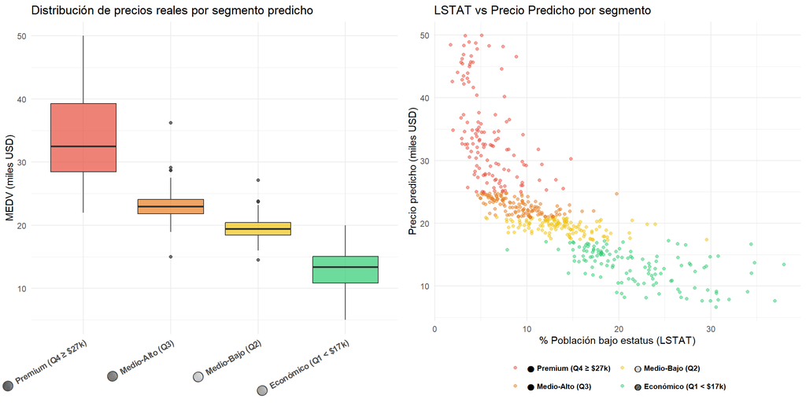

```r
p_seg1 <- ggplot(datos_acc, aes(x = segmento, y = medv, fill = segmento)) +
  geom_boxplot(alpha = 0.7, show.legend = FALSE) +
  scale_fill_manual(values = c("#e74c3c","#e67e22","#f1c40f","#2ecc71")) +
  labs(title = "Distribución de precios reales por segmento predicho",
       x = NULL, y = "MEDV (miles USD)") +
  theme_minimal() +
  theme(axis.text.x = element_text(angle = 30, hjust = 1, size = 9, face = "bold"))

p_seg2 <- ggplot(datos_acc, aes(x = lstat, y = pred_medv, color = segmento)) +
  geom_point(alpha = 0.5, size = 1.5) +
  scale_color_manual(values = c("#e74c3c","#e67e22","#f1c40f","#2ecc71")) +
  labs(title = "LSTAT vs Precio Predicho por segmento",
       x = "% Población bajo estatus (LSTAT)", y = "Precio predicho (miles USD)",
       color = NULL) +
  theme_minimal() +
  theme(
    legend.position  = "bottom",
    legend.text      = element_text(size = 8, face = "bold"),
    legend.key.size  = unit(0.5, "cm"),
    legend.spacing.x = unit(0.3, "cm")
  ) +
  guides(color = guide_legend(nrow = 2))

grid.arrange(p_seg1, p_seg2, ncol = 2)
```

**Interpretación de Plot segmentación**

**Boxplot:** separación limpia entre segmentos sin solapamiento de medianas, el modelo discrimina con precisión los cuatro rangos de precio. El segmento Premium muestra mayor dispersión (rango 25–50k), reflejando heterogeneidad estructural en viviendas de alto valor.

## 10.3 Marco de acciones por segmento

Framework de intervención inmobiliaria

| Segmento | Precio Predicho | Perfil clave | Acción recomendada | Equipo |
| --- | --- | --- | --- | --- |
| 🔴 Premium | ≥ Q4 (~$27k+) | LSTAT bajo, RM alto | Tasación premium, marketing focalizado | Banca Hipotecaria / Inversión |
| 🟠 Medio-Alto | Q3 | LSTAT medio-alto, RM moderado | Créditos hipotecarios estándar + mejora habitacional | Crédito Retail |
| 🟡 Medio-Bajo | Q2 | LSTAT medio, crim baja | Programas de subsidio + financiamiento largo plazo | Política habitacional |
| 🟢 Económico | ≤ Q1 (~$17k) | LSTAT alto, crim alta | Subsidio directo + intervención urbana | Gobierno / Municipio |

## 10.4 Análisis de viviendas con mayor error de predicción

```r
# Viviendas donde el modelo se equivoca más = zonas de alta heterogeneidad
top_error <- datos_acc |>
  mutate(abs_residuo = abs(residuo)) |>
  arrange(desc(abs_residuo)) |>
  slice_head(n = 15) |>
  select(medv, pred_medv, residuo, lstat, rm, crim, nox, segmento)

top_error |>
  knitr::kable(
    caption = "Top 15 viviendas con mayor error absoluto de predicción",
    digits  = 2,
    col.names = c("Precio Real", "Precio Predicho", "Residuo",
                  "LSTAT", "Habitaciones", "Criminalidad", "NOX", "Segmento")
  )
```

Top 15 viviendas con mayor error absoluto de predicción

| Precio Real | Precio Predicho | Residuo | LSTAT | Habitaciones | Criminalidad | NOX | Segmento |
| --- | --- | --- | --- | --- | --- | --- | --- |
| 50.0 | 29.80 | 20.20 | 9.53 | 6.22 | 9.23 | 0.63 | 🔴 Premium (Q4 ≥ $27k) |
| 50.0 | 34.62 | 15.38 | 3.26 | 4.97 | 4.90 | 0.63 | 🔴 Premium (Q4 ≥ $27k) |
| 36.2 | 24.63 | 11.57 | 9.45 | 6.14 | 0.07 | 0.49 | 🟠 Medio-Alto (Q3) |
| 37.6 | 46.87 | -9.27 | 3.13 | 8.04 | 0.38 | 0.50 | 🔴 Premium (Q4 ≥ $27k) |
| 15.0 | 24.25 | -9.25 | 10.11 | 5.76 | 51.14 | 0.60 | 🟠 Medio-Alto (Q3) |
| 27.1 | 18.39 | 8.71 | 19.15 | 6.17 | 0.14 | 0.52 | 🟡 Medio-Bajo (Q2) |
| 50.0 | 42.54 | 7.46 | 3.70 | 7.93 | 2.01 | 0.60 | 🔴 Premium (Q4 ≥ $27k) |
| 50.0 | 42.61 | 7.39 | 1.92 | 7.80 | 1.83 | 0.60 | 🔴 Premium (Q4 ≥ $27k) |
| 50.0 | 42.87 | 7.13 | 2.96 | 7.02 | 6.54 | 0.63 | 🔴 Premium (Q4 ≥ $27k) |
| 44.0 | 37.28 | 6.72 | 3.11 | 7.45 | 0.02 | 0.39 | 🔴 Premium (Q4 ≥ $27k) |
| 28.7 | 22.31 | 6.39 | 9.69 | 6.64 | 0.07 | 0.55 | 🟠 Medio-Alto (Q3) |
| 23.7 | 17.41 | 6.29 | 29.55 | 5.41 | 0.29 | 0.49 | 🟡 Medio-Bajo (Q2) |
| 32.5 | 26.40 | 6.10 | 5.68 | 6.56 | 0.10 | 0.49 | 🔴 Premium (Q4 ≥ $27k) |
| 7.0 | 12.77 | -5.77 | 23.97 | 5.41 | 0.18 | 0.61 | 🟢 Económico (Q1 < $17k) |
| 29.0 | 34.70 | -5.70 | 4.74 | 7.04 | 0.06 | 0.40 | 🔴 Premium (Q4 ≥ $27k) |

**Accionabilidad:**

Las 15 viviendas con mayor error absoluto revelan tres patrones estructurales que el modelo identifica con precisión y que tienen implicaciones directas para la gestión del portafolio inmobiliario.

El segmento Premium concentra 9 de 15 casos: XGBoost detecta sistemáticamente viviendas con precio real de $50k que el mercado valora entre ~30k y ~43k, con residuos de hasta 20.20 . el modelo está señalando activos subvalorados en el segmento de mayor valor, información accionable para estrategias de adquisición y tasación diferenciada.

La criminalidad extrema emerge como variable no lineal de alto impacto: la vivienda con criminalidad 51.14 presenta un residuo de -9.25, donde el modelo predice $24.25k frente a un precio real de $15k. Machine Learning cuantifica aquí un descuento por riesgo que los modelos lineales clásicos no capturan abriendo oportunidades de intervención urbana con retorno social medible.

Los residuos negativos en Premium (-9.27 y -5.70) identifican propiedades con perfil de alto valor pero precio real moderado, posiblemente por deterioro o microubicación, activos con potencial de revalorización que el modelo señala para revisión prioritaria.

> **Acción directa:** las 15 viviendas de esta tabla representan los casos donde la inteligencia del modelo es más valiosa, candidatas a auditoría especializada y estrategia de valoración individualizada. —

# 11 Resumen Ejecutivo

```r
data.frame(
  Componente = c("Dataset","Variables candidatas","Variables seleccionadas",
                 "Métodos de selección","Mejor modelo (RMSE test)",
                 "Mejor R² test","Variables clave"),
  Resultado  = c(
    paste0(nrow(datos)," obs × ",ncol(datos)," variables"),
    as.character(length(vars_pred)),
    paste0(k_optimo," (",paste(vars_sel,collapse=", "),")"),
    "Fisher J + Pearson + Cov. Norm. → SFS → Branch & Bound",
    results$Modelo[which.min(results$RMSE)],
    round(max(results$R2),4),
    paste(names(sort(imp_avg,decreasing=TRUE))[1:3],collapse=", ")
  )
) |> knitr::kable(caption="Resumen ejecutivo")
```

Resumen ejecutivo

| Componente | Resultado |
| --- | --- |
| Dataset | 506 obs × 14 variables |
| Variables candidatas | 13 |
| Variables seleccionadas | 7 (crim, zn, indus, chas, nox, rm, lstat) |
| Métodos de selección | Fisher J + Pearson + Cov. Norm. → SFS → Branch & Bound |
| Mejor modelo (RMSE test) | XGBoost |
| Mejor R² test | 0.8607 |
| Variables clave | rm, lstat, crim |

# 12 Conclusiones

Los tres algoritmos demuestran capacidad predictiva **sólida** (R² entre 0.82 y 0.86 en test), resultado coherente con un pipeline de selección de características que reduce la dimensionalidad de 13 a 7 variables sin pérdida significativa de rendimiento. El pipeline integra criterios individuales (Fisher J, correlación de Pearson, covarianza normalizada) con búsqueda secuencial (SFS) y búsqueda exacta (Branch & Bound), garantizando que cada modelo opera sobre el subconjunto óptimo con justificación matemática formal.

**Recomendación:** XGBoost con variables seleccionadas ofrece el mejor balance entre precisión y generalización (RMSE = 3.668, R² = 0.861). Para implementación en producción, monitorear el error en las 15 viviendas atípicas identificadas como casos de alta heterogeneidad estructural.

# 13 Referencias

- Harrison, D., & Rubinfeld, D.L. (1978). *Hedonic prices and the demand for clean air*. JEEM, 5(1), 81–102.
- Breiman, L. (2001). *Random Forests*. Machine Learning, 45(1), 5–32.
- Friedman, J.H. (2001). *Greedy Function Approximation: A Gradient Boosting Machine*. AoS, 29(5), 1189–1232.
- Chen, T., & Guestrin, C. (2016). *XGBoost*. KDD ’16.
- **Mery, D.** Reconocimiento de Patrones — Selección de características. DCC PUC Chile. https://domingomery.ing.puc.cl/teaching/patrones/

*Documento generado con Quarto • R • ggplot2 • igraph*

*Alejandro Figueroa Rojas — Data Science & Business Intelligence* *El valor del Machine Learning no está en el modelo que converge,* *sino en la decisión que fundamenta.*